# Praca domowa 2

Elissa Hallak

## Dane

Dane wykorzystane w Pracy domowej 2 opisują wycenę nieruchmości. Każda obserwacja jest pewną nieruchmością, która posiada informacje takie jak powierzchnia, liczba pokoi, liczba łazienek i wiele więcj. Opis wszystkich kolumn w pliku `README.md`.

## Zadanie 1

Jak wygląda rozkład ceny nieruchomości w poszczególnych kodach pocztowych na przestrzeni lat? Rozważamy kody pocztowe, które mają więcej niż 280 posiadłości.

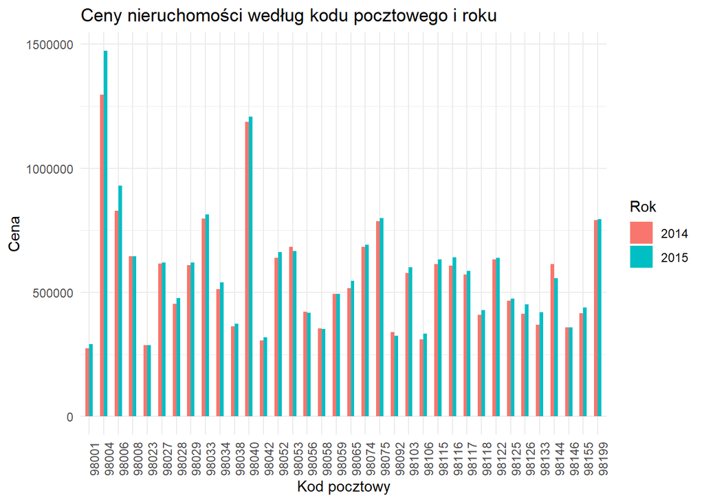

```r
df %>%
  group_by(zipcode) %>%
  count(zipcode, name = "count") %>%
  filter(count>280) %>%
  left_join(df, by = 'zipcode') %>%
  mutate(date = as.POSIXct(date, format = "%Y%m%dT%H%M%S")) %>%
  mutate(year = format(date, "%Y")) %>%
  select(zipcode, year, price) %>%
  group_by(zipcode, year) %>%
  summarise(average = mean(price)) %>%
  arrange(zipcode)%>%
  ggplot(aes(x = as.factor(zipcode), y = average, fill = as.factor(year))) +
  geom_col(position = 'dodge', width = 0.5) +
  labs(title = "Ceny nieruchomości według kodu pocztowego i roku",
       x = "Kod pocztowy",
       y = "Cena",
       fill = "Rok") +
  theme_minimal() +
  theme(axis.text.x = element_text(angle = 90))
```

**Komentarz:** Patrząc po kodach pocztowych w większości z nich widać wzrost średniej ceny mieszkań między rokiem 2014 a 2015 (słupek znajdujacy się po lewo jest mniejszy niż ten po prawo)

## Zadanie 2

Czy jest różnica w rozkładzie ceny nieruchomości od powierzchni mieszkalnej uwzględniając podział na nieruchomości z piwnicą i bez?

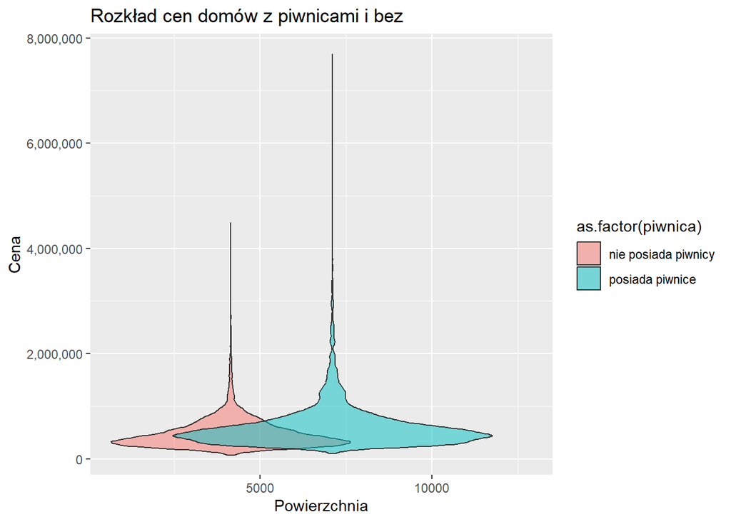

```r
#zakladam ze piwnica nalezy do powierzchni mieszkalnej (czyli powierzchnia mieszkalna = sqft_living)

df %>%
  select(price, sqft_living, sqft_basement) %>%
  mutate(piwnica = ifelse(sqft_basement>0, "posiada piwnice", "nie posiada piwnicy")) %>%
  select(price, sqft_living, piwnica) %>%
  ggplot(aes(x = sqft_living, y = price, fill = as.factor(piwnica))) +
  geom_violin(alpha = 0.5)+
  labs(title = "Rozkład cen domów z piwnicami i bez",
       x = 'Powierzchnia',
       y = "Cena") +
  scale_y_continuous(labels = scales::comma)+
  scale_color_manual(values = c("nie posiada piwnicy" = "red","posiada piwnice" = "blue"), name = "Posiadanie piwnicy")
```

**Komentarz:** Domy z piwnicą mają bardziej rozciągnięty rozkład i występują w wyższych przedziałach cenowych w porównaniu do domów bez piwnicy, które mają węższy przedział cenowy i są skoncentrowane w niższych zakresach cen przy mniejszych powierzchniach.

## Zadanie 3

Jaka jest zależność pomiędzy jakością wykończenia nieruchomości a liczbą pięter?

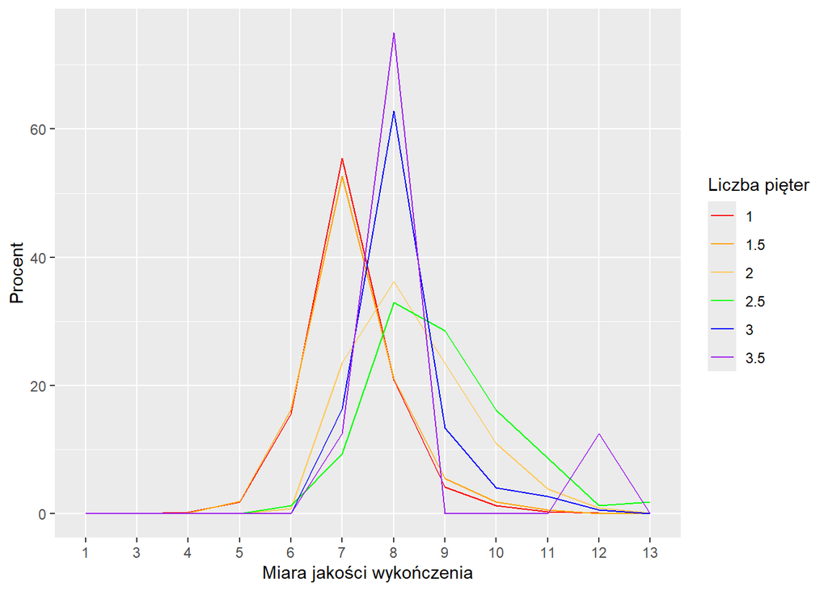

```r
A <- df %>%
  select(floors, grade, id) %>%
  group_by(floors, grade) %>%
  summarise(count = n())

B <- as.data.frame(unique(df$grade))
names(B) <- 'grade'

df %>%
  select(floors, grade, id) %>%
  group_by(floors) %>%
  summarise(count = n()) %>%
  left_join(A, by = 'floors') %>%
  mutate(percentage =round(count.y/count.x*100,2)) %>%
  select(floors, grade, percentage) %>%
  complete(floors, grade, fill = list(percentage = 0)) %>%
  ggplot(aes(x = as.factor(grade), y = percentage, group = as.factor(floors), color = as.factor(floors))) +
  geom_line()+
  scale_color_manual(values = c(
    "1" = "red",
    "1.5" = "orange",
    "2" = "#FFCA5B",
    "2.5" = "green",
    "3" = "blue",
    "3.5" = "purple"),
    name = "Liczba pięter") +
  labs(x = "Miara jakości wykończenia",
       y = "Procent")
```

**Komentarz:**

Jeśli prześledzimy wykres od lewej strony, to linie reprezentujące niższe piętra zaczynają się “łamać” w górę wcześniej niż reszta, czyli istniejące budynki o jakości mniejszej niż 5 mają 1/1.5 piętra. Następnie widać, że szczyty linii reprezentujących budynki o mniejszej ilości pięter (1/1.5) znajdują się przy jakości 7. Reszta znajduje się przy jakości 8, zatem budynki o ilości pięter >=2 mają lepszą jakość niż te niższe.

## Zadanie 4

Jaka jest zależność między powierzchnią mieszkalną nieruchomości a powierzchnią gruntu w podziale na liczbę sypialni?

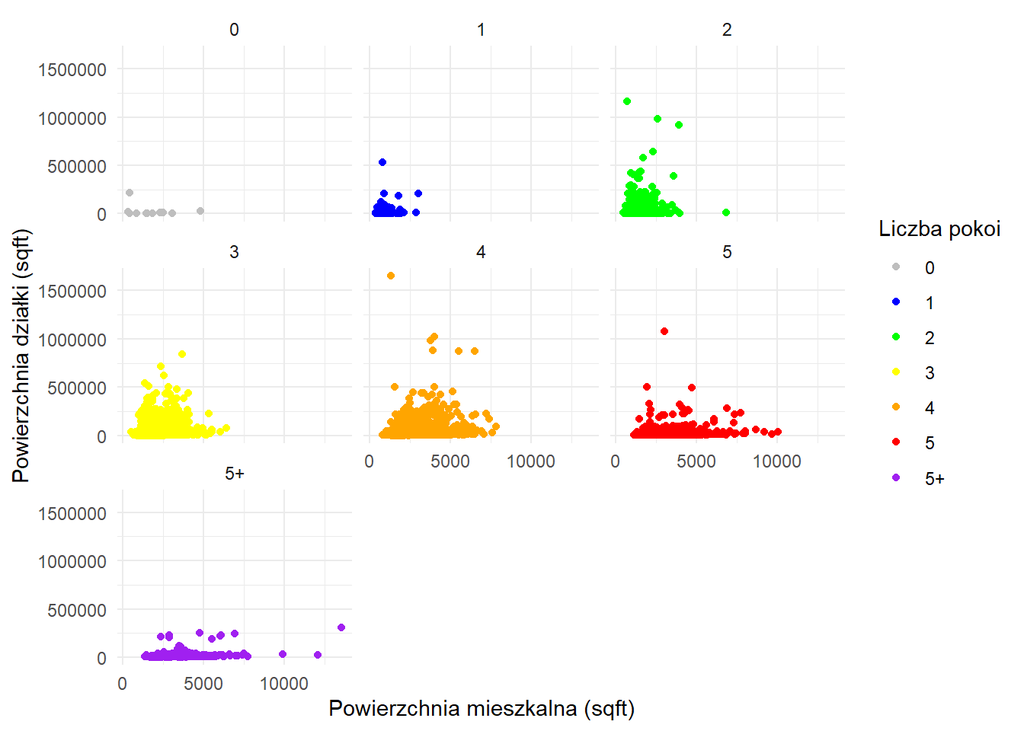

```r
df %>%
  mutate(bedrooms_cat = ifelse(bedrooms > 5, "5+", as.character(bedrooms))) %>%
  select(sqft_lot, sqft_living, bedrooms_cat) %>%
  ggplot(aes(x = sqft_living, y = sqft_lot, color = bedrooms_cat)) +
  geom_point() +
  scale_color_manual(values = c("0" = "gray", "1" = "blue", "2" = "green", "3" = "yellow", "4" = "orange", "5" = "red", "5+"   = "purple"), name = "Liczba pokoi") +
  facet_wrap(. ~ bedrooms_cat) +
  theme_minimal() +
  labs(x = "Powierzchnia mieszkalna (sqft)",
       y = "Powierzchnia działki (sqft)")
```

## Zadanie 5

Rozważmy tylko nieruchomości, które miały remont. W której dekadzie było najwięcej przeprowadzonych remontów? Czy w poszczególnych dekadach jest porównywalny procent nieruchmości dla każdej wartości miary jakości i wykończenia nieruchomości?

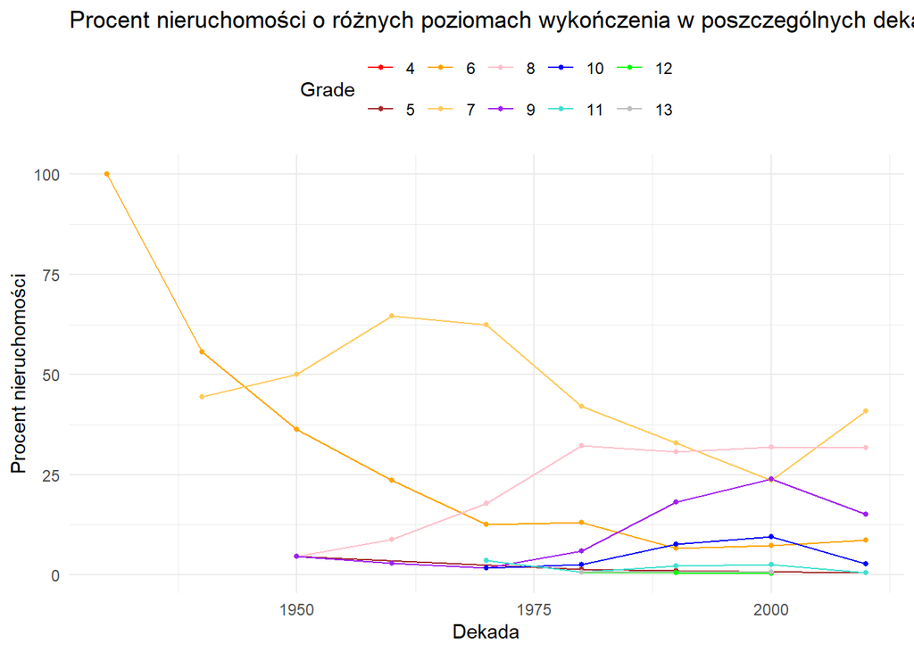

```r
A <- df %>%
  filter(yr_renovated!=0) %>%
  mutate(decade = (yr_renovated %/% 10) * 10) %>%
  select(id, decade) %>%
  group_by(decade) %>%
  summarise(count = n()) %>%
  arrange(count)

df %>%
  filter(yr_renovated!=0) %>%
  mutate(decade = (yr_renovated %/% 10) * 10) %>%
  select(decade, grade) %>%
  group_by(decade, grade) %>%
  summarise(count = n()) %>%
  left_join(A, by = 'decade') %>%
  mutate(percentage = round(count.x/count.y*100,2)) %>%
  select(decade, grade, percentage) %>%
  ggplot(aes(x = decade, y = percentage, color = as.factor(grade), group = as.factor(grade))) +
  geom_line(linewidth = 0.5) +
  geom_point(size = 1) +
  labs(
    title = "Procent nieruchomości o różnych poziomach wykończenia w poszczególnych dekadach",
    x = "Dekada",
    y = "Procent nieruchomości",
    color = "Grade"
  ) +
  theme_minimal() +
  theme(legend.position = "top")+
  scale_color_manual(values = c(
    "12" = "green",
    "10" = "blue",
    "6" = "orange",
    "9" = "purple",
    "8" = "pink",
    "7" = "#FFCA5B",
    "5" = "brown",
    "13" = "gray",
    "11" = "turquoise",
    "4" = "red"
  ))
```

```r
#liczylam kazda dekade osobno
```

## Zadanie 6

Jak prezentuje się wartość minimalna, średnia i maksymalna ceny nieruchmości w podziele na rok budowy nieruchomości.

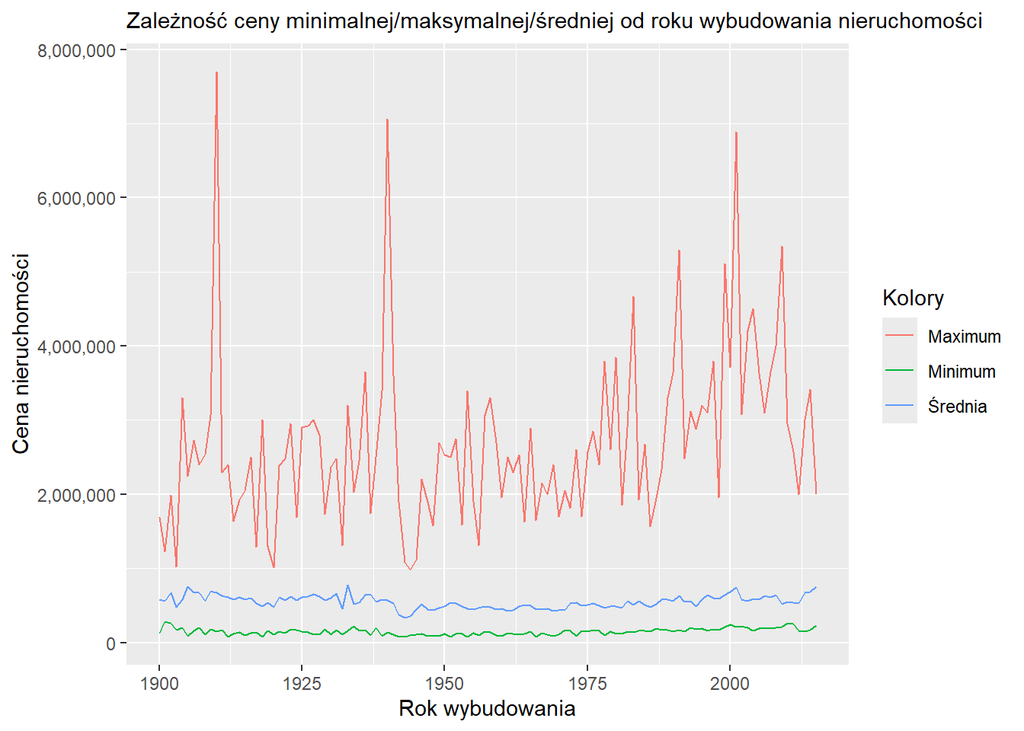

```r
df %>%
  select(price, yr_built) %>%
  group_by(yr_built) %>%
  mutate(minimum = min(price),
         maximum = max(price),
         average = mean(price)) %>%
  arrange(yr_built) %>%
  select(-price) %>%
  distinct() %>%
  ggplot(aes(x = yr_built)) +
  geom_line(aes(y = maximum, color = 'Maximum')) +
  geom_line(aes(y = minimum, color = 'Minimum')) +
  geom_line(aes(y = average, color = 'Średnia')) +
  labs(title = "Zależność ceny minimalnej/maksymalnej/średniej od roku wybudowania nieruchomości",
       x = "Rok wybudowania",
       y = "Cena nieruchomości",
       color = "Kolory")+
  theme(plot.title = element_text(size = 11))+
  scale_y_continuous(labels = scales::comma)
```

**Komentarz:** Wartość minimalna i średnia na przestrzeni lat nie zmieniała sie za bardzo, natomiast cena maksymalna zmieniała sie bardzo gwałtownie (np. ok 1940 lub 1910 widać spadki ceny o ponad 5 000 000 dolarów)